# Chapter 1: Sensor data smoothing and filtering

Most sensor data is affected to some extent by noise. In this tutorial, we show you a few examples of noisy signals and describe several techniques to remove noise from the signal. These techniques are also described in the corresponding chapter.

```python
import glob
import matplotlib
from matplotlib import cm
import sys
import math
import numpy as np
import pandas as pd
import pylab as pl
from biosppy.signals import ecg
from scipy import signal

import matplotlib.pyplot as plt
from scipy.signal import butter, lfilter, freqz, iirnotch, filtfilt, firwin

matplotlib.style.use('ggplot')
%matplotlib notebook
import mpld3
mpld3.enable_notebook()
```

## Example 1: Noisy accelerometer signals

In the first example, we will look at removing noise from an accelerometer signal captured from a phone in the pocket while an individual is walking. There are many sources of noise in accelerometer signals from a smartphone or smartwatch/fitness band. The main noise sources are because the phone is moving around in your pocket or bag while walking, or a wristband moving a little on your wrist as you move it.

Even if you are stationary, there are micro-tremors of the hand or body that are picked up by the accelerometer. In some cases, there are also external noise sources. For example, if you are on an elevator, some of the vibrations of the elevator are transmitted to your phone and captured by it. Similarly, when a phone is placed on a desk, the vibrations of the HVAC system are often transmitted to the phone. This noise needs to be removed before you can further process the signal.

```python
def pull_data(dir_name, file_name):
    f = open(dir_name + '/' + file_name + '.csv')
    xs = []
    ys = []
    zs = []
    rs = []
    timestamps = []
    for line in f:
        value = line.split(',')
        if len(value) > 3:
            timestamps.append(float(value[-4]))
            x = float(value[-3])
            y = float(value[-2])
            z = float(value[-1])
            r = math.sqrt(x ** 2 + y ** 2 + z ** 2)
            xs.append(x)
            ys.append(y)
            zs.append(z)
            rs.append(r)
    return np.array(xs), np.array(ys), np.array(zs), np.array(rs), np.array(timestamps)
```

## Time-domain noise removal: Moving Average Filter

Many sources of noise tend to be random in nature. Informally, this means that the noise has roughly equal amounts of positive and negative changes, and there is no pattern in the noise over time.

In this case, noise can be reduced by weighted averaging the values. For example, take the case where you are writing an algorithm to determine the rotation of the screen of the mobile phone. Since you have noise due to small hand movements (if you are holding the phone), you may perform a weighted average of every 10 samples readings and use the smoothed signal in the application to determine whether the screen has rotated. In this way, the noise in the acceleration signal is reduced.

We are going to try to smooth the data with a moving average filter, which is a simple filter where the weights are all one. The function "convolve" takes a window corresponding to the moving average weights and essentially multiplies it with the data. The result is the smoothed signal. There are two key parameters to think about when designing an averaging filter. The first is the window size and the second is the set of weights.

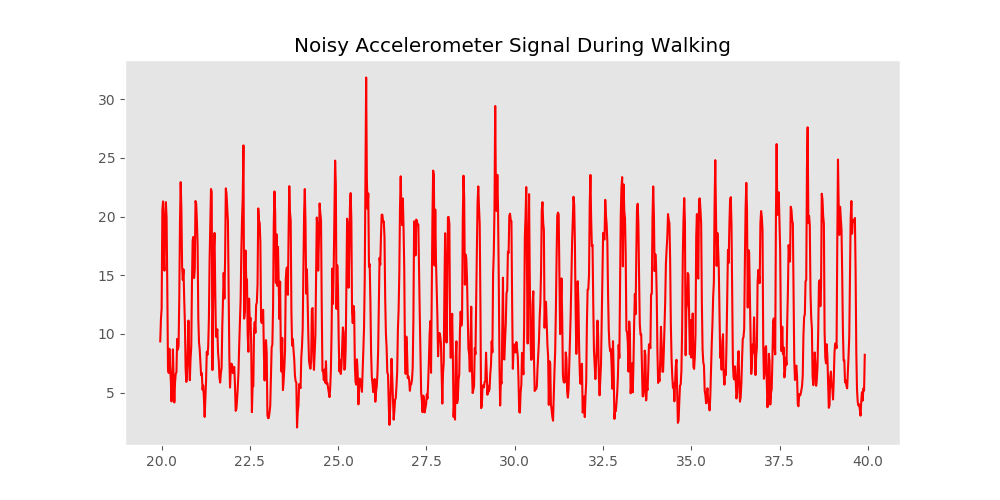

```python
# read accelerometer data file
accel_file = 'data/inPocket-Steps'
x_data, y_data, z_data, signal, timestamps = pull_data(accel_file, 'accelerometer')

c = timestamps[0]
timestamps = (timestamps - c)/1000000000

signal = signal[1000:2000]
timestamps = timestamps[1000:2000]

plt.figure(figsize=(10,5))
pl.plot(timestamps, signal, 'r-',label='unfiltered')
plt.title("Noisy Accelerometer Signal During Walking")
pl.grid()
pl.show()
```

#### Parameters: Window size and weights

There are two key parameters to think about when designing an averaging filter. The first is the window size and the second is the set of weights.

- **Window size**: The window size determines how much smoothing is performed on the signal. In the example below, we are going to replace each sample by the average of a window of ten samples around it. We could have averaged more nearby points to smooth even more aggressively. As you increase the smoothing window, the signal will look cleaner and more visually pleasing, but beware of using too large a window since you will smooth out the important characteristics of the signal (for example, steps if you want to do step detection). Try increasing window size and see the effect.
- **Weights**: The moving average smoothing in the example below gives equal weight to the set of values that are averaged. np.ones((window_size,))/window_size gives a weight of 1/10 to each of the samples in the example below. But you can construct other filters by varying the weights. For example, the idea in exponential smoothing is to assign exponentially decreasing weights as the observation get older. In other words, recent observations are given relatively more weight than the older observations.

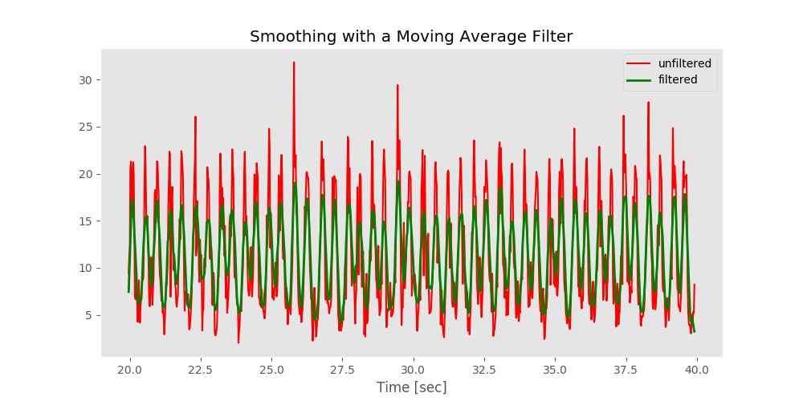

```python
# Moving average with window size
window_size = 10
filtered_signal = np.convolve(signal, np.ones((window_size,))/window_size, mode='same')

plt.figure(figsize=(10,5))
plt.title("Smoothing with a Moving Average Filter")
plt.plot(timestamps, signal, 'r-', label='unfiltered')
plt.plot(timestamps, filtered_signal, 'g-', linewidth=2, label='filtered')
plt.xlabel('Time [sec]')
plt.grid()
plt.legend()
plt.show()
```

## Frequency-domain filtering: Butterworth Filter

Let us now turn to noise in the frequency domain. Frequency-domain noise can be removed by a combination of frequency filters. A low-pass filter can remove high frequency components while letting through low frequency components. A high pass filter does the reverse and lets high frequency components through while removing low frequency components. A notch filter removes a specific frequency from the signal.

We are now going to use a filter called a 'butterworth filter' to remove noise. A Butterworth filter is a popular frequency domain 'lowpass' filter that can remove high frequency noise while only letting the low frequencies through. Since the walking signal is low frequency (only a few steps minute), this is a good approach.

```python
# Filter requirements.
order = 5
fs = 50.0  # sample rate, Hz
cutoff = 3.667  # desired cutoff frequency of the filter, Hz

# Filter the data, and plot both the original and filtered signals.
nyq = 0.5 * fs
normal_cutoff = cutoff / nyq
b, a = butter(order, normal_cutoff, btype='low', analog=False)
filtered_signal = filtfilt(b, a, signal)
```

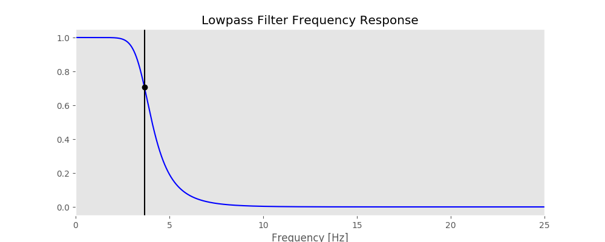

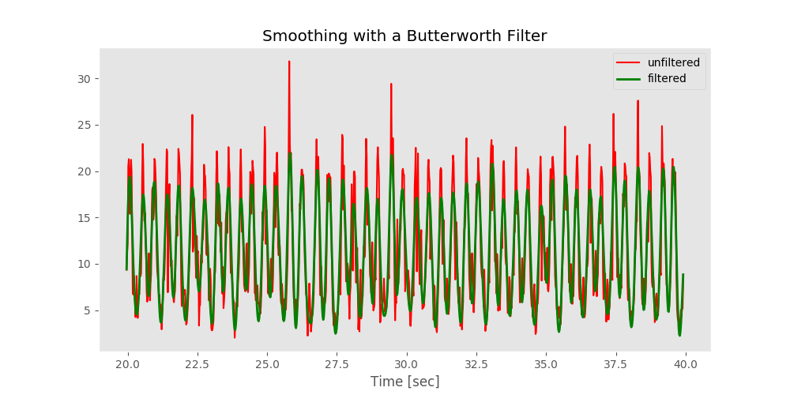

```python
# Frequency response graph
w, h = freqz(b, a, worN=8000)
plt.figure(figsize=(10,4))

plt.plot(0.5 * fs * w / np.pi, np.abs(h), 'b')
plt.plot(cutoff, 0.5 * np.sqrt(2), 'ko')
plt.axvline(cutoff, color='k')
plt.xlim(0, 0.5 * fs)
plt.title("Lowpass Filter Frequency Response")
plt.xlabel('Frequency [Hz]')
plt.grid()
plt.show()

plt.figure(figsize=(10,5))
plt.title("Smoothing with a Butterworth Filter")
plt.plot(timestamps, signal, 'r-', label='unfiltered')
plt.plot(timestamps, filtered_signal, 'g-', linewidth=2, label='filtered')
plt.xlabel('Time [sec]')
plt.grid()
plt.legend()

plt.show()
```

## Example 2: Noisy ECG signals

In the second example, we will look at removing noise from an ECG trace. This signal is a Lead I ECG signal acquired at 1000 Hz, with a resolution of 12 bit. Although of good quality, it exhibits powerline noise interference, has an offset resulting from the acquisition device, and we can also observe the influence of breathing in the variability of peak amplitudes.

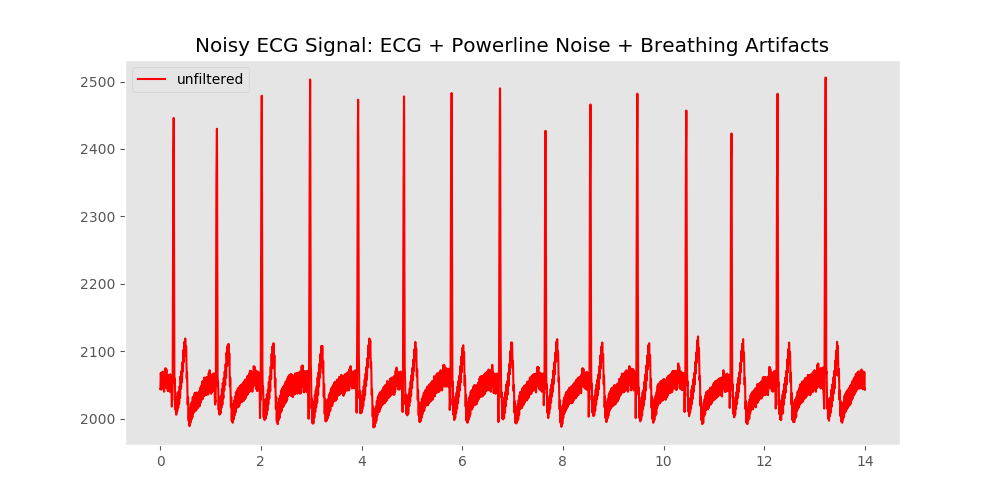

```python
plt.figure(figsize=(10,5))
signal = np.loadtxt('data/ECG-Trace/ecg.txt')
sampling_rate =1000
N = len(signal) # number of samples
T = (N - 1) / sampling_rate # duration
ts = np.linspace(0, T, N, endpoint=False) # relative timestamps
pl.plot(ts, signal, 'r-',label='unfiltered')
plt.title("Noisy ECG Signal: ECG + Powerline Noise + Breathing Artifacts")
pl.legend(loc='upper left')
pl.grid()
pl.show()
```

### Moving Average Filter

We are going to try to smooth ECG with a simple moving average filter. But since the noise is due to periodic signals like powerline interference and breathing, moving average is not effective.

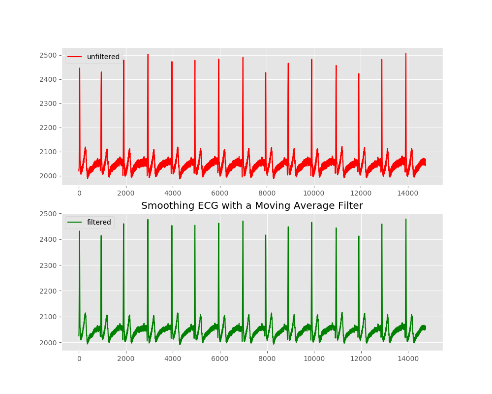

```python
# Moving average with window size
window_size = 10
filtered_signal = np.convolve(signal, np.ones((window_size,))/window_size, mode='valid')

fig, ax = plt.subplots(2, 1, figsize=(10, 8))
ax[0].plot(signal[250:], 'r-', label='unfiltered')
ax[0].legend(loc='upper left')
ax[1].plot(filtered_signal[250:], 'g-', linewidth=1.5, label='filtered')
ax[1].legend(loc='upper left')
ax[1].set_title("Smoothing ECG with a Moving Average Filter")
plt.show()
```

### Frequency-domain filtering

A classic example of how these frequency domain filters are used for noise removal is in the case of ECG filtering, so let us discuss how this works. There are three sources of noise in the ECG data shown above

- **Baseline Wander**: Baseline wander is a low-frequency component present in the ECG system which causes the signal to “wander” off from the actual ECG waveform.
- **Powerline Noise**: The frequency of alternating current in the electrical mains is typically around 50-60Hz. Since this is in the frequency range of the ECG signal that we are interested in, it appears as a significant source of noise that can disrupt any measurement that we wish to make.
- **High frequency Noise**: Various other electronic equipment in the vicinity of the ECG sensor including pacemakers, mobile phones, and other electronics can interfere with the ECG signal. These sources of noise are high frequency, and need to be removed by an appropriately selected low-pass filter.

[figure not shown]

#### Band pass filter to remove baseline wander and high-frequency noise

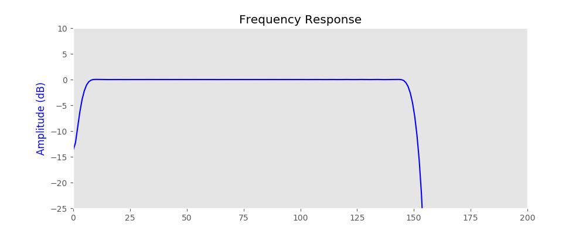

```python
# remove baseline wander caused by breathing
fs = sampling_rate  # Sample frequency (Hz)
order = int(0.3 * sampling_rate)
if order % 2 == 0: order += 1

# the cutoff frequencies for the filter.
f1, f2 = 3, 150

# remember to normalize the frequencies to nyquist.
f1 = 2. * f1 / sampling_rate
f2 = 2. * f2 / sampling_rate

a = np.array([1])
b = firwin(order,[f1, f2],pass_zero=False)

# Frequency response
w, h = freqz(b, a)
# Generate frequency axis
freq = w*fs/(2*np.pi)
# Plot
plt.figure(figsize=(10,4))
plt.plot(freq, 20*np.log10(abs(h)), color='blue')
plt.title("Frequency Response")
plt.ylabel("Amplitude (dB)", color='blue')
plt.xlim([0, 200])
plt.ylim([-25, 10])
plt.grid()
plt.show()
```

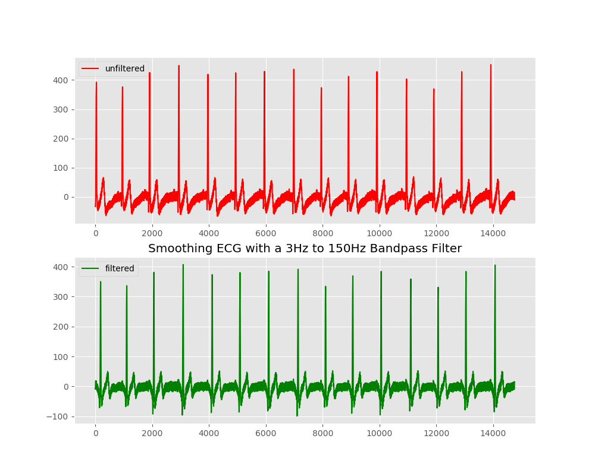

```python
signal = signal - np.mean(signal)
bp_signal = lfilter(b, a, signal)

fig, ax = plt.subplots(2, 1, figsize=(10, 8))
ax[0].plot(signal[250:], 'r-', label='unfiltered')
ax[0].legend(loc='upper left')
ax[1].plot(bp_signal[250:], 'g-', linewidth=1.5, label='filtered')
ax[1].set_title("Smoothing ECG with a 3Hz to 150Hz Bandpass Filter")
ax[1].legend(loc='upper left')
plt.show()
```

#### Notch filter to remove 50Hz noise

We will now remove powerline noise using a 50Hz notch filter.

```python
fs = sampling_rate  # Sample frequency (Hz)
f0 = 50.0  # Frequency to be removed from signal (Hz)
Q = 8.0  # Quality factor
w0 = f0/(fs/2)  # Normalized Frequency
# Design notch filter
b, a = iirnotch(w0, Q)
```

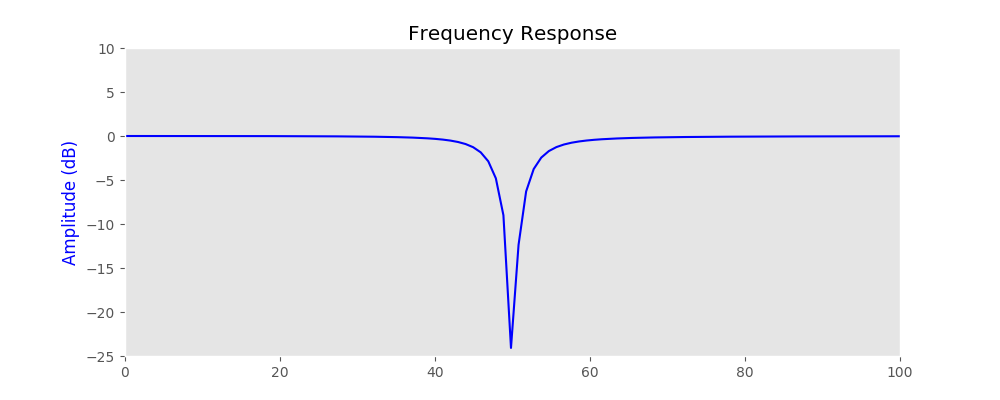

```python
# Frequency response
w, h = freqz(b, a)
# Generate frequency axis
freq = w*fs/(2*np.pi)
# Plot
plt.figure(figsize=(10,4))
plt.plot(freq, 20*np.log10(abs(h)), color='blue')
plt.title("Frequency Response")
plt.ylabel("Amplitude (dB)", color='blue')
plt.xlim([0, 100])
plt.ylim([-25, 10])
plt.grid()
plt.show()
```

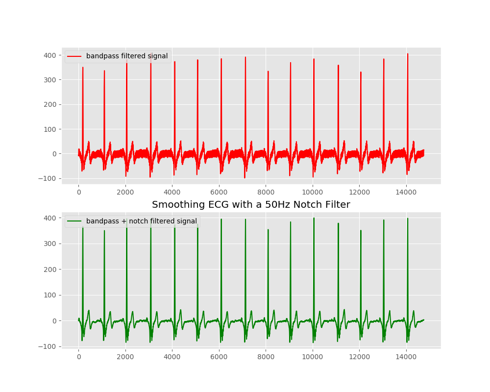

```python
nf_signal = lfilter(b, a, bp_signal)
fig, ax = plt.subplots(2, 1, figsize=(10, 8))
ax[0].plot(bp_signal[250:], 'r-', label='bandpass filtered signal')
ax[0].legend(loc='upper left')
ax[1].plot(nf_signal[250:], 'g-', linewidth=1.5, label='bandpass + notch filtered signal')
ax[1].set_title("Smoothing ECG with a 50Hz Notch Filter")
ax[1].legend(loc='upper left')
plt.show()
```